# tcplfit2 Vignette

Center for Computational Toxicology and Exposure

# Getting started with tcplfit2

The package tcplfit2 contains the core concentration-response functionality of the package tcpl (The ToxCast Pipeline) built to process all of the ToxCast high-throughput screen (HTS) data at the US EPA. Much of the rest of the code in tcpl is used to do data processing, normalization, and database storage. We wanted to reuse the core concentration-response code for other projects, and add extensions to it, which was the origin of the current package `tcplfit2`. The main set of extensions was to include all of the concentration-response models that are contained in the program BMDExpress. These include exponential and power functions in addition to the original Hill, gain-loss and constant models. Additionally, we wanted to include BMD (Benchmark Dose Modeling) outputs, which is simply defining a Benchmark Response (BMR) level and setting the BMD to the concentration where the curve crosses the BMR level. One final addition was to let the hitcall value be a continuous number ranging from 0 to 1. This vignette describes some functionality of the `tcplfit2` package with a few simple examples.

## Example 1: Running a single concentration-response calculation

All calculations use the function `concRespCore` which has several key inputs. The first set are put into a named list called ‘row’:

- `conc` - a vector of concentrations (not log concentrations)
- `resp` - a vector of responses, of the same length as `conc`. Note that replicates are allowed, i.e. there can be multiple pairs of conc and resp with the same concentration value.
- `cutoff`- this is the value that the response must exceed before a a curve can be called a hit. For ToxCast, this is usually some multiple (typically 3) of the median absolute deviation (BMAD) around baseline for the lowest two concentration. The user is free to make other choices
- `bmed` - this is the median of the baseline, and will usually be set to zero. If not, the entire response series will be shifted by this amount.
- `onesd`- This is one standard deviation of the nose around the baseline. The BMR value = `onesd`*`bmr_scale`. The default `bmr_scale` is 1.349.

The function `concRespCore` can also have other optional elements which will be included in the output. These can be, for instance, the name of the chemical (or other identifiers) or the name of the assay being modeled. Two other parameters might be used. The first is a Boolean `conthits`. If TRUE (the default, and recommended usage), the hitcall returned will be a continuous value between 0 and 1. The other is `do.plot`. If this is set to TRUE (default is FALSE), a plot of the curve will be generated. The user can also select only a subset of the models to be run. The example below has all of the possible ones included. the model `cnst` always needs to be included. For some applications, we exclude the `gnls` model.

To run a simple example, use the following code …

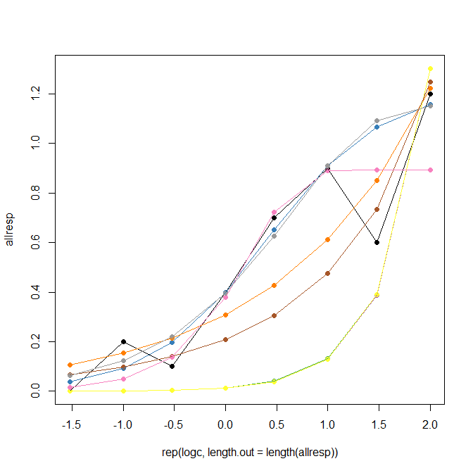

```r
  conc <- list(.03,.1,.3,1,3,10,30,100)
  resp <- list(0,.2,.1,.4,.7,.9,.6, 1.2)
  row = list(conc = conc, resp = resp, bmed = 0, cutoff = 1, onesd = .5,name="some chemical")
  res <- concRespCore(row,fitmodels = c("cnst", "hill", "gnls", "poly1", "poly2", "pow", "exp2", "exp3",
                                        "exp4", "exp5"),conthits = T, do.plot=T)
```

The output of this run will be a data frame with one row, summarizing the results for the winning model.

## Example 2: Running a series of concentration-response models for a single assay

The input data for this example is taken from one of the Tox21 HTS assays, for estrogen receptor (ER) agonist activity. The data is from the mc3 table in the database `invitrodb`, which is the back end for `tcpl`. This example will run 6 chemicals out of the 100 that are included in the data set, and will create plots for these. The plotting routine `concRespPlot` is somewhat generic, and we anticipate that users will make their own version of this. To run this example, use the following code …

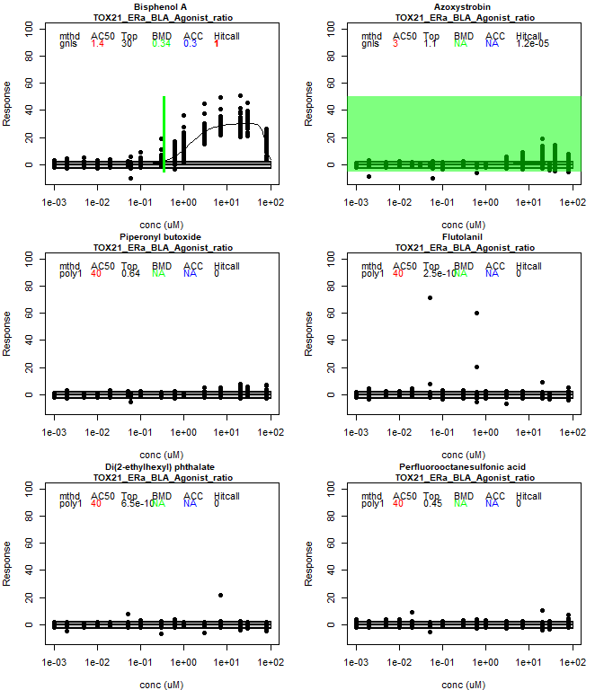

```r
  # read in the data
  # Loading in the level 3 example data set from invitrodb
  data("mc3")

  # set up a 3 x 2 grid for the plots
  oldpar <- par(no.readonly = TRUE)
  on.exit(par(oldpar))
  par(mfrow=c(3,2),mar=c(4,4,2,2))

  # determine the background variation
  temp <- mc3[mc3$logc<= -2,"resp"]
  bmad <- mad(temp)
  onesd <- sd(temp)
  cutoff <- 3*bmad

  # select six samples. Note that there may be more than one sample processed for a given chemical
  spid.list <- unique(mc3$spid)
  spid.list <- spid.list[1:6]

  for(spid in spid.list) {
    # select the data for just this sample
    temp <- mc3[is.element(mc3$spid,spid),]

    # The data file has stored concentration in log10 form, so fix that
    conc <- 10**temp$logc
    resp <- temp$resp

    # pull out all of the chemical identifiers and the name of the assay
    dtxsid <- temp[1,"dtxsid"]
    casrn <- temp[1,"casrn"]
    name <- temp[1,"name"]
    assay <- temp[1,"assay"]

    # create the row object
    row <- list(conc = conc, resp = resp, bmed = 0, cutoff = cutoff, onesd = onesd,assay=assay,dtxsid=dtxsid,casrn=casrn,name=name)

    # run the concentration-response modeling for a single sample
    res <- concRespCore(row,fitmodels = c("cnst", "hill", "gnls", "poly1", "poly2", "pow", "exp2", "exp3",
                                          "exp4", "exp5"),conthits = T, aicc = F,bidirectional=F)

    # plot the results
    concRespPlot(res,ymin=-10,ymax=100)
  }
```

One would typically save the result rows in a data frame end export these for further analysis. You could remove the plotting function from the current loop and have a loop that read from the overall results data frame and only plot selected results (e.g. those with significant responses).

## Example 3: Plotting concentration-response modeling on transcriptional signatures

The input data for this example contains 6 signatures for one chemical in a transcriptomics data set. This data set is a sample from the signature scoring method that provides the cutoff, one standard deviation, and the concentration-response data. The example illustrates two kinds of plots available in `tcplfit2`. In the call to `concRespCore()`, the argument `do.plot` is set to `TRUE`, which provides a simple plot showing results of all the different curve fitting methods. Next, utilizing the function `concRespPlot()` provides a more informative plot for the winning model.

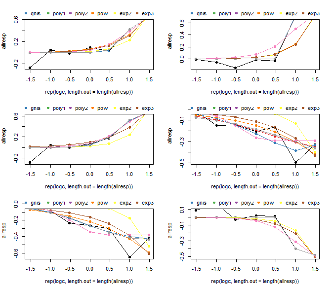

```r
  # call additional R packages
  library(stringr)  # string management package

  # read in the file
  data("signatures")

  # set up a 3 x 2 grid for the plots
  oldpar <- par(no.readonly = TRUE)
  on.exit(par(oldpar))
  par(mfrow=c(3,2),mar=c(4,4,2,2))

  # fit 6 observations in signatures
  for(i in 1:nrow(signatures)){
    # set up input data
    row = list(conc=as.numeric(str_split(signatures[i,"conc"],"\\|")[[1]]),
               resp=as.numeric(str_split(signatures[i,"resp"],"\\|")[[1]]),
               bmed=0,
               cutoff=signatures[i,"cutoff"],
               onesd=signatures[i,"onesd"],
               name=signatures[i,"name"],
               assay=signatures[i,"signature"])
    # run concentration-response modeling (1st plotting option)
    out = concRespCore(row,conthits=F,do.plot=T)
    if(i==1){
      res <- out
    }else{
      res <- rbind.data.frame(res,out)
    }
  }
```

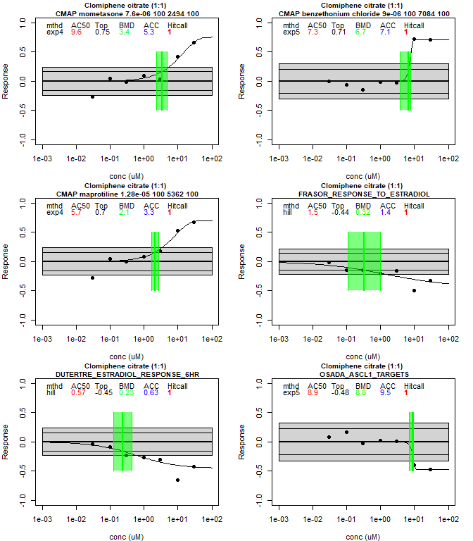

```r
  # set up a 3 x 2 grid for the plots
  oldpar <- par(no.readonly = TRUE)
  on.exit(par(oldpar))
  par(mfrow=c(3,2),mar=c(4,4,2,2))
  # plot results using `concRespPlot`(2nd plotting option)
  for(i in 1:nrow(res)){
    concRespPlot(res[i,],ymin=-1,ymax=1)
  }
```

## Example 4: Running tcpl-like multi-concentration response data without a database connection

The ToxCast pipeline `tcpl` is an R package that manages, curve-fits, plots, and stores ToxCast data to populate its linked MySQL database, InvitroDB. The original `tcplFit()` function within `tcpl` performed basic concentration response curve fitting. Processing with tcpl_v3 and beyond depends on `tcplfit2` to allow a wider variety of concentration-response models when using `invitrodb` in the 4.0 schema and beyond. Within this update, `tcplLite` became deprecated within `tcpl` because `tcplFit2` can be used to curve-fit data and make hitcalls independent of invitrodb, as the example below illustrates. For additional information, please consult vignettes for `library(tcpl)` at https://CRAN.R-project.org/package=tcpl.

The input for this example comes from the ACEA_AR assay. Data from the assay component ACEA_AR_agonist_80hr was analyzed in the positive analysis fitting direction relative to DMSO as the neutral control and baseline of activity. Using a electrical impedance as a cell growth reporter, increased activity can be used to infer increased signaling at the pathway-level for the androgen receptor (as encoded by the AR gene). Given heterogeneous assay data, source data often must go through pre-processing steps to transform into a uniform data format, often like this level 0. The below table is identical to the multi-concentration level 0 data (mc0) table that would be seen in `invitrodb` and recognized by `tcpl`. Columns include:

- m0id = Level 0 id
- spid = Sample id
- acid = Unique assay component id; unique numeric id for each assay component
- apid = Assay plate id
- coli = Column index (location on assay plate)
- rowi = Row index (location on assay plate)
- wllt = well type
- wllq = well quality
- conc = concentration
- rval = raw value
- srcf = Source file name
- clowder_uid = clowder unique id for source files
- git_hash = hash key for pre-processing scripts

```r
# Loading in the level 0 example data set from invitrodb
data("mc0")
library(data.table)
library(DT)
dat <- mc0
DT::datatable(head(dat[wllt=='t',]),rownames= FALSE, options = list(scrollX = T))
```

| m0id | spid | acid | apid | rowi | coli | wllt | wllq | conc | rval | srcf | clowder_uid | git_hash |
| --- | --- | --- | --- | --- | --- | --- | --- | --- | --- | --- | --- | --- |
| 519762672 | TP0001364A01 | 1829 | Experiment.ID:1502051323HT1_A113641_AP01_RA_P09 | 13 | 3 | t | 1 | 0.138 | 3.12223683963748 | ACEA/source/TO1_800_AR_mc_20141231/1502051323HT1_A113641_AP01_RA_P09.xlsx |  |  |
| 519762768 | TP0001364A02 | 1829 | Experiment.ID:1502051323HT1_A113641_AP01_RA_P09 | 13 | 5 | t | 1 | 0.138 | 3.84260554743345 | ACEA/source/TO1_800_AR_mc_20141231/1502051323HT1_A113641_AP01_RA_P09.xlsx |  |  |
| 519762864 | TP0001364A03 | 1829 | Experiment.ID:1502051323HT1_A113641_AP01_RA_P09 | 13 | 7 | t | 1 | 0.138 | 4.32871864587724 | ACEA/source/TO1_800_AR_mc_20141231/1502051323HT1_A113641_AP01_RA_P09.xlsx |  |  |
| 519762960 | TP0001364A04 | 1829 | Experiment.ID:1502051323HT1_A113641_AP01_RA_P09 | 13 | 9 | t | 1 | 0.138 | 4.26783180585688 | ACEA/source/TO1_800_AR_mc_20141231/1502051323HT1_A113641_AP01_RA_P09.xlsx |  |  |
| 519763056 | TP0001364A05 | 1829 | Experiment.ID:1502051323HT1_A113641_AP01_RA_P09 | 13 | 11 | t | 1 | 0.138 | 4.53262917268075 | ACEA/source/TO1_800_AR_mc_20141231/1502051323HT1_A113641_AP01_RA_P09.xlsx |  |  |
| 519763152 | TP0001364A06 | 1829 | Experiment.ID:1502051323HT1_A113641_AP01_RA_P09 | 13 | 13 | t | 1 | 0.055 | 4.53943356408973 | ACEA/source/TO1_800_AR_mc_20141231/1502051323HT1_A113641_AP01_RA_P09.xlsx |  |  |

To run standalone `tcplfit2` fitting without the need for a MySQL database connection like `invitrodb`, the user will replicate stepping through the multiple levels of processing. A detailed explanation of processing levels can be found within `tcpl`’s Data Processing vignette.

Level 1 importantly establishes the concentration index. The concentration index is simply the distinct concentrations ranked from lowest to highest, and this index can be used to calculate the baseline median absolute deviation for an assay.

```r
library(tcpl)
setkeyv(dat, c('acid', 'srcf', 'apid', 'coli', 'rowi', 'spid', 'conc'))

## Define replicate id (rpid) column for test compound wells
nconc <- dat[wllt == "t" , ## denotes test well as the well type (wllt)
             list(n = lu(conc)), #total number of unique concentrations
             by = list(acid, apid, spid)][ , list(nconc = min(n)), by = acid]
dat[wllt == "t" & acid %in% nconc[nconc > 1, acid],
    rpid := paste(acid, spid, wllt, srcf, apid, "rep1", conc, sep = "_")]
dat[wllt == "t" & acid %in% nconc[nconc == 1, acid],
    rpid := paste(acid, spid, wllt, srcf, "rep1", conc, sep = "_")]

## Define rpid column for non-test compound wells
dat[wllt != "t",
    rpid := paste(acid, spid, wllt, srcf, apid, "rep1", conc, sep = "_")]

## set repid based on rowid
dat[, dat_rpid := rowid(rpid)]
dat[, rpid := sub("_rep[0-9]+.*", "",rpid, useBytes = TRUE)]
dat[, rpid := paste0(rpid,"_rep",dat_rpid)]

# Define concentration index
indexfunc <- function(x) as.integer(rank(unique(x))[match(x, unique(x))])
dat[ , cndx := indexfunc(conc), by = list(rpid)]
```

### Adjustments

Levels 2 and 3 are used for data adjustments and normalization. Generally if the response values (rval) need to be logged or transformed in some way from their original values this is where that adjustment would occur. However, in this case, the corrected value (cval) is identical to the original response values (rval).

```r
# If no adjustments are required for the data, the corrected value (cval) should be set as original rval
dat[,cval := rval]

## Poor well quality (wllq) wells should be removed
dat <- dat[!wllq == 0,]

## Fitting generally cannot occur if response values are NA therefore values need to be removed
dat <- dat[!is.na(cval),]

## A column for log10 concentration is added as some of the mc3 methods require logc. Given logging concentration, conc=0 are not allowed therefore a dummy non-zero value should be used
dat[conc == 0 , conc := 0.0001]
dat[ , logc := log10(conc)]

#As a final step to prepare the dataset tcplfit2 processing, a dummy aeid is required if using mc3_mthds from tcpl
dummy_aeid <- 99999
dat[,aeid := dummy_aeid]

## Set aeid as a key
setkey(dat,aeid)
```

Once the data is initialized to a point where the required fields are available, the methods included in the `tcpl` package can be identified and applied without the need for a database connection. You can see the list of available methods for Level 3 in the table below:

```r
mthd_funcs <- tcpl:::mc3_mthds()
DT::datatable(tcpl::tcplMthdList(3),rownames= FALSE, options = list(scrollX = T))
```

| mc3_mthd_id | mc3_mthd | desc |
| --- | --- | --- |
| 1 | none | apply no level 3 method |
| 2 | bval.apid.lowconc.med | plate-wise baseline based on low conc median value |
| 3 | pval.apid.medpcbyconc.max | plate-wise median response of positive control (max) |
| 4 | pval.apid.medpcbyconc.min | plate-wise median response of positive control (min) |
| 5 | resp.pc | response percent activity |
| 6 | resp.multneg1 | multiply the response by -1 |
| 7 | resp.log2 | take the log base 2 of the response |
| 8 | resp.mult25 | multiply the response by 25 |
| 9 | resp.fc | calculate response as fold-change |
| 11 | bval.apid.nwlls.med | plate-wise baseline based on neutral ctrl median value |

[output cut: 27 more lines]

### Normalization

Here three normalization methods are selected and applied to the data. Note because of the way `tcpl` handles the application of functions, the dataframe must be called `dat`. In the future, `tcpl` will export these functions so that they can be applied to any dataset without the need for a specific name or dummy aeid.

```r
# apply level 3 methods
## These methods directly apply the normalization methods from tcpl without the need for a DB connection
lapply(mthd_funcs[["bval.apid.nwlls.med"]](dummy_aeid), eval)
lapply(mthd_funcs[["pval.apid.medncbyconc.min"]](dummy_aeid),eval)
lapply(mthd_funcs[["resp.pc"]](dummy_aeid),eval)
```

Level 4 determines the baseline variability, or noise, that will later be used for cutoff calculation. Using the established concentration index, the level 4 methods can be loaded in a similar way to level 3.

```r
mthd_funcs_l4 <- tcpl:::mc4_mthds()
DT::datatable(tcpl::tcplMthdList(4), rownames= FALSE, options = list(scrollX = T))
```

| mc4_mthd_id | mc4_mthd | desc |
| --- | --- | --- |
| 1 | bmad.aeid.lowconc.twells | bmad based on two lowest concentration of treatment wells |
| 2 | bmad.aeid.lowconc.nwells | bmad based on two lowest concentration of nwells |

There are much fewer level 4 methods, but generally it is a requirement to assign a method that calculates the bmad and assign a method that calculates the standard deviation of the noise for `tcplfit2` fitting.

```r
# apply level 4 methods
## These methods directly apply the noise calculation and fitting methods from tcpl without the need for a DB connection
lapply(mthd_funcs_l4[["bmad.aeid.lowconc.twells"]](),eval)
lapply(mthd_funcs_l4[["onesd.aeid.lowconc.twells"]](),eval)
lapply(mthd_funcs_l4[["bidirectional.false"]](),eval)
```

### Dose-Response Curve Fitting

After methods up to level 4 have been applied, the model fitting can begin. In `tcpl`, this would be considered level 4, and is where `tcplfit2` is used to fit all of the models as a dependency for `tcpl`.

```r
#do tcplfit2 fitting
myfun <- function(y) {
  res <- tcplfit2::tcplfit2_core(y$conc,
                          y$resp,
                          cutoff = unique(y$bmad),
                          bidirectional = TRUE,
                          verbose = FALSE,
                          force.fit = TRUE,
                          fitmodels = c("cnst", "hill", "gnls", "poly1",
                                        "poly2", "pow", "exp2", "exp3",
                                        "exp4", "exp5")
                          )
  list(list(res)) #use list twice because data.table uses list(.) to look for values to assign to columns
}
```

**Warning: The fitting step for the full data set, `dat`, can take 7-10 minutes to run.** Hence we will provide a subset of data for curve fitting and hitcalling. The subset data only contains records of six samples.

```r
# only want to run tcplfit2 for test wells in this case
# this chunk doesn't run, fit the curves on the subset below
dat[wllt == 't',params:= myfun(.SD), by = .(spid)]
```

```r
# create a subset that contains 6 samples and run curve fitting
subdat <- dat[spid %in% unique(spid)[10:15],]
subdat[wllt == 't',params:= myfun(.SD), by = .(spid)]
```

### Continuous Hitcalling

After all of the models have been fit, hitcalling can occur. The output of level 4 can be fed directly into the `tcplhit2_core` function. The results are then pivoted and shown in the resulting datatable.

```r
myfun2 <- function(y) {
  res <- tcplfit2::tcplhit2_core(params = y$params[[1]],
                                 conc = y$conc,
                                 resp = y$resp,
                                 cutoff = 3*unique(y$bmad),
                                 onesd = unique(y$osd)
                                 )
  list(list(res))
}

# continute with hitcalling
res <- subdat[wllt == 't', myfun2(.SD), by = .(spid)]

#pivot wider
res_wide <- rbindlist(Map(cbind, spid = res$spid, res$V1))

DT::datatable(res_wide,options = list(scrollX = T))
```

|  | spid | n_gt_cutoff | cutoff | fit_method | top_over_cutoff | rmse | a | b | tp | p | q | ga | la | er | bmr | bmdl | bmdu | caikwt | mll | hitcall | ac50 | ac50_loss | top | ac5 | ac10 | ac20 | acc | ac1sd | bmd | … |
| --- | --- | --- | --- | --- | --- | --- | --- | --- | --- | --- | --- | --- | --- | --- | --- | --- | --- | --- | --- | --- | --- | --- | --- | --- | --- | --- | --- | --- | --- | --- |
| 1 | TP0001366A03 | 0 | 49.2830638452227 | gnls | 0.281901000511745 | 8.12511963559894 |  |  | -25.2616327130339 | 0.300000001034866 | 1.1277485785509 | 0.120675126521391 | 3.81608258484109 | 1.98905247064609 | 33.9132650800971 |  |  | 0.00208943205745552 | -85.6714534334205 | 0 | 0.00477742508368088 | 6.39137615623954 | -13.8929450062525 |  |  |  |  |  |  | … |
| 2 | TP0001366A04 | 0 | 49.2830638452227 | poly1 | 0.285116813596597 | 14.8933395805865 | 0.42196486870353 |  |  |  |  |  |  | 2.51117022960903 | 33.9132650800971 | 49.3661536586937 | 237.348407111574 | 0.180422901324317 | -99.5153531887808 | 1.56536710902145e-09 | 16.65 |  | 14.0514301278276 | 1.665 | 3.33 | 6.66 |  | 59.5773744604806 | 80.3698781471884 | … |
| 3 | TP0001366A05 | 0 | 49.2830638452227 | gnls | 0.230579663036236 | 9.8021833586969 |  |  | -17.0767315742384 | 0.300000000048306 | 4.055990640644 | 0.124889758460193 | 3.94936105182377 | 2.13196253698476 | 33.9132650800971 |  |  | 0.230506069221482 | -89.7068736755676 | 0 | 0.0122778226713923 | 4.15378706341692 | -11.3636722548247 |  |  |  |  |  |  | … |
| 4 | TP0001366A06 | 0 | 49.2830638452227 | poly1 | 0.130144380745061 | 11.1839204176555 | 0.19261002478546 |  |  |  |  |  |  | 2.29827763252166 | 33.9132650800971 | 68.7229706022903 |  | 0.629210055042992 | -93.5208634895674 | 9.75399148300407e-11 | 16.65 |  | 6.41391382535582 | 1.665 | 3.33 | 6.66 |  | 130.520511691536 | 176.072170271883 | … |
| 5 | TP0001366A07 | 0 | 49.2830638452227 | gnls | 0.25480547525408 | 8.86452058842676 |  |  | -12.5575945136781 | 7.98842631852464 | 7.9999986953221 | 0.0167893679648239 | 3.91623536169883 | 1.89813253015055 | 33.9132650800971 |  |  | 0.00148372909623819 | -85.8405179284853 | 0 | 0.0167893674048174 | 3.91623536237081 | -12.5575945050592 |  |  |  |  |  |  | … |
| 6 | TP0001366A08 | 0 | 49.2830638452227 | gnls | 0.440022924941614 | 7.45675844926627 |  |  | -29.8245869314839 | 7.98596120556591 | 0.353240646376545 | 0.083649130537124 | 2.64521777979504 | 1.86978547363224 | 33.9132650800971 |  |  | 2.45711096575871e-07 | -80.0457583161288 | 0 | 0.0824132481469447 | 12.9099530041626 | -21.6856779032592 |  |  |  |  |  |  | … |

*The same hitcalling can be done with the full data set, `dat`, as well.*